# DS152 Tutorial Sheet 6

## Exercise 1

We will work with the Swiss banknotes dataset and perform logistic regression to determine whether the status of a bank note is genuine or counterfeit, based on six predictors related to measurements made on the bills.

```r
library(tidyverse)
library(mclust)
glimpse(banknote)
```

```
Rows: 200
Columns: 7
$ Status   <fct> genuine, genuine, genuine, genuine, genuine, genuine, genuine…
$ Length   <dbl> 214.8, 214.6, 214.8, 214.8, 215.0, 215.7, 215.5, 214.5, 214.9…
$ Left     <dbl> 131.0, 129.7, 129.7, 129.7, 129.6, 130.8, 129.5, 129.6, 129.4…
$ Right    <dbl> 131.1, 129.7, 129.7, 129.6, 129.7, 130.5, 129.7, 129.2, 129.7…
$ Bottom   <dbl> 9.0, 8.1, 8.7, 7.5, 10.4, 9.0, 7.9, 7.2, 8.2, 9.2, 7.9, 7.7, …
$ Top      <dbl> 9.7, 9.5, 9.6, 10.4, 7.7, 10.1, 9.6, 10.7, 11.0, 10.0, 11.7, …
$ Diagonal <dbl> 141.0, 141.7, 142.2, 142.0, 141.8, 141.4, 141.6, 141.7, 141.9…
```

**(a)** Run the code below to add a binary (0,1) variable to the dataset called `status_binary` where the value is 0 when the Status is counterfeit and 1 when the Status is genuine.

```r
banknote <- banknote %>%
              mutate(status_binary = as.numeric(Status == "genuine"))
glimpse(banknote)
```

```
Rows: 200
Columns: 8
$ Status        <fct> genuine, genuine, genuine, genuine, genuine, genuine, ge…
$ Length        <dbl> 214.8, 214.6, 214.8, 214.8, 215.0, 215.7, 215.5, 214.5, …
$ Left          <dbl> 131.0, 129.7, 129.7, 129.7, 129.6, 130.8, 129.5, 129.6, …
$ Right         <dbl> 131.1, 129.7, 129.7, 129.6, 129.7, 130.5, 129.7, 129.2, …
$ Bottom        <dbl> 9.0, 8.1, 8.7, 7.5, 10.4, 9.0, 7.9, 7.2, 8.2, 9.2, 7.9, …
$ Top           <dbl> 9.7, 9.5, 9.6, 10.4, 7.7, 10.1, 9.6, 10.7, 11.0, 10.0, 1…
$ Diagonal      <dbl> 141.0, 141.7, 142.2, 142.0, 141.8, 141.4, 141.6, 141.7, …
$ status_binary <dbl> 1, 1, 1, 1, 1, 1, 1, 1, 1, 1, 1, 1, 1, 1, 1, 1, 1, 1, 1,…
```

**(b)** Replace [A], [B] and [C] in the code below to create a scatter point plot showing `status_binary` as the response variable and `Top` as a predictor. Do you think `Top` predictors for separating the counterfeit from the genuine notes?

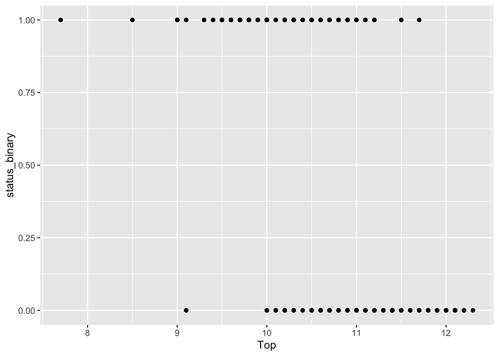

```r
ggplot(banknote, aes(x = Top, y = status_binary)) +
  geom_point()
```

“Genuine” is the reference group here. From the graph, it appears that as Top increases the chance of being a genuine note decreases.

**(c)** Split the data into 85% training and 15% test data by replacing [A], [B], [C], [D] and [E] in the following code. Set the seed to 10465.

```r
library(rsample)
set.seed(10465)
bank_split <- initial_split(banknote, prop = 0.85)

train_bank_data <- training(bank_split)
test_bank_data  <- testing(bank_split)
```

**(d)** Replace [A], [B], [C] and [D] in the code below to fit a simple logistic regression model to the training data, using `status_binary` as the response variable and `Top` as a predictor.

```r
logistic_model <- glm(status_binary ~ Top,
                    family = binomial,
                    data = train_bank_data)
logistic_model
```

```
Call:  glm(formula = status_binary ~ Top, family = binomial, data = train_bank_data)

Coefficients:
(Intercept)          Top
     25.664       -2.416

Degrees of Freedom: 169 Total (i.e. Null);  168 Residual
Null Deviance:      235.6
Residual Deviance: 159  AIC: 163
```

**Note for tutors:** Remind students that we use `glm` for logistic regression rather than `lm`. Highlight the use of the training data for fitting the model rather than the full dataset.

**(e)** Set up a threshold of 0.50 for classifying banknotes as genuine based on the test data set by replacing [A] and [B] in the following code.

```r
bank_res <- test_bank_data %>%
            select(Status, status_binary) %>%
            mutate(pred_p = predict(logistic_model,
                                    type = "response", newdata = test_bank_data)) %>%
            mutate(pred_status = ifelse(pred_p >= 0.5,"genuine","counterfeit"))
bank_res
```

```
        Status status_binary     pred_p pred_status
1      genuine             1 0.92193446     genuine
2      genuine             1 0.63087725     genuine
3      genuine             1 0.45292194 counterfeit
4      genuine             1 0.28623810 counterfeit
5      genuine             1 0.57306421     genuine
6      genuine             1 0.81794016     genuine
7      genuine             1 0.45292194 counterfeit
8      genuine             1 0.95036554     genuine
9      genuine             1 0.98051882     genuine
10     genuine             1 0.51318350     genuine
11     genuine             1 0.81794016     genuine
12     genuine             1 0.57306421     genuine
13     genuine             1 0.45292194 counterfeit
14     genuine             1 0.51318350     genuine
```

[output cut: 16 more lines]

**Note for tutors:** Highlight the use of the test data for getting predictions from the model rather than the full dataset.

**(f)** Create a confusion table by running the code below. What is the accuracy?

```r
N <- nrow(bank_res)

confusion_mat <- table(bank_res %>% select(Status, pred_status))
confusion_mat
```

```
             pred_status
Status        counterfeit genuine
  counterfeit          10       3
  genuine               4      13
```

```r
accuracy <- (confusion_mat %>% diag %>% sum)/N
accuracy
```

```
[1] 0.7666667
```

**(g)** Now rerun all of the above but instead use a multiple logistic regression model with `Top` and `Diagonal` as predictors. Which model indicates the best performance when it comes to distinguishing counterfeit notes from genuine ones?

```r
logistic_model2 <- glm(status_binary ~ Top + Diagonal,
                    family = binomial,
                    data = train_bank_data)
logistic_model2
```

```
Call:  glm(formula = status_binary ~ Top + Diagonal, family = binomial,
    data = train_bank_data)

Coefficients:
(Intercept)          Top     Diagonal
   -850.438       -1.957        6.205

Degrees of Freedom: 169 Total (i.e. Null);  167 Residual
Null Deviance:      235.6
Residual Deviance: 17.78    AIC: 23.78
```

```r
#### Update bank_res from earlier with prediction from model 2
bank_res <- bank_res %>%
            mutate(pred_p2 = predict(logistic_model2,
                                    type = "response", newdata = test_bank_data)) %>%
            mutate(pred_status2 = ifelse(pred_p2 >= 0.5,"genuine","counterfeit"))
bank_res
```

```
        Status status_binary     pred_p pred_status      pred_p2 pred_status2
1      genuine             1 0.92193446     genuine 9.999979e-01      genuine
2      genuine             1 0.63087725     genuine 9.999649e-01      genuine
3      genuine             1 0.45292194 counterfeit 9.995938e-01      genuine
4      genuine             1 0.28623810 counterfeit 9.997887e-01      genuine
5      genuine             1 0.57306421     genuine 9.999876e-01      genuine
6      genuine             1 0.81794016     genuine 9.998079e-01      genuine
7      genuine             1 0.45292194 counterfeit 9.997815e-01      genuine
8      genuine             1 0.95036554     genuine 9.999992e-01      genuine
9      genuine             1 0.98051882     genuine 9.993964e-01      genuine
10     genuine             1 0.51318350     genuine 9.183236e-01      genuine
11     genuine             1 0.81794016     genuine 9.977071e-01      genuine
12     genuine             1 0.57306421     genuine 9.998523e-01      genuine
13     genuine             1 0.45292194 counterfeit 9.995938e-01      genuine
14     genuine             1 0.51318350     genuine 9.749300e-01      genuine
```

[output cut: 16 more lines]

```r
confusion_mat2 <- table(bank_res %>% select(Status, pred_status2))
confusion_mat2
```

```
             pred_status2
Status        counterfeit genuine
  counterfeit          13       0
  genuine               0      17
```

```r
accuracy2 <- (confusion_mat2 %>% diag %>% sum)/N
accuracy2
```

```
[1] 1
```

## Exercise 2

We will consider data on crime rates by US state. This data set contains arrests per 100,000 residents for assault and murder in each of the 50 US states in 1973. A glimpse of the dataset, called `arrests_dat`, is displayed below:

```r
library(tidyverse)
arrests_dat <- read_csv("https://www.dropbox.com/s/8dc41ynd12fwvhr/arrests_dat.csv?raw=1")
glimpse(arrests_dat)
```

```
Rows: 50
Columns: 3
$ state   <chr> "Alabama", "Alaska", "Arizona", "Arkansas", "California", "Col…
$ murder  <dbl> 13.2, 10.0, 8.1, 8.8, 9.0, 7.9, 3.3, 5.9, 15.4, 17.4, 5.3, 2.6…
$ assault <dbl> 236, 263, 294, 190, 276, 204, 110, 238, 335, 211, 46, 120, 249…
```

**(a)** To visualise the data, what would you replace [A], [B], [C] and [D] in the code below with to create this plot?

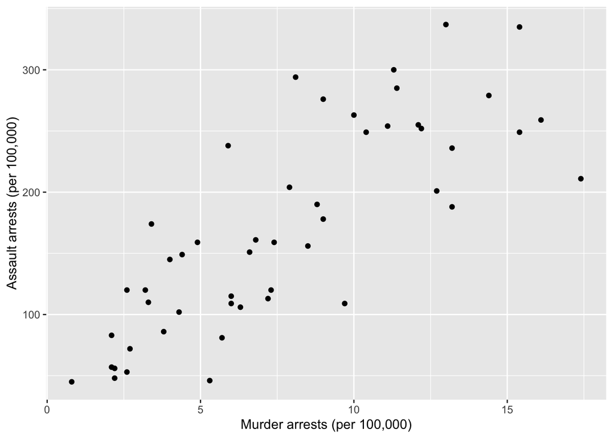

```r
ggplot(arrests_dat, aes(x = murder, y = assault)) +
  geom_point() +
  xlab("Murder arrests (per 100,000)") +
  ylab("Assault arrests (per 100,000)")
```

**(b)** Now, let’s perform k-means clustering. Firstly, we will create a new dataset that contains only the `murder` and `assault` variables from the `arrests_dat` dataset. Then we will run the k-means algorithm with 2 clusters on this data. Replace [E],[F] and [G] in the code such that this objective can be achieved.

```r
arrests_dat2 <- arrests_dat %>%
                  dplyr::select(murder, assault)

kmean_res <- kmeans(arrests_dat2, centers = 2)
```

**(c)** Next we want to visualise the clustering results. What would you replace [H], [I], [J] in the code below to create this plot?

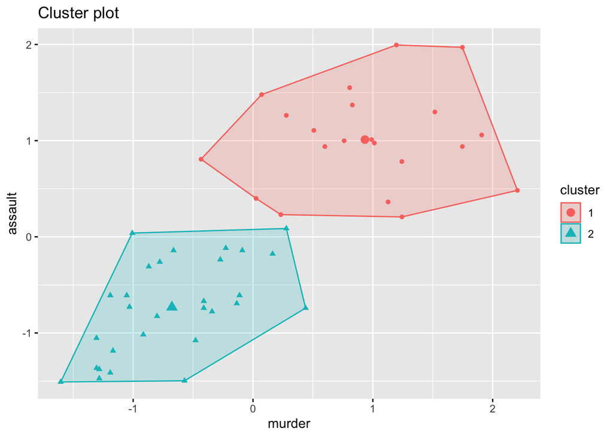

```r
library(factoextra)
fviz_cluster(kmean_res , data = arrests_dat2, geom = "point")
```